# S&P 500: R&D Analysis

# Brandon Hsu

Investing and using your money to make money is now more popular and wide known than ever (especially with the crippling prices of houses and increased inflation these days). Investing is more than just buying links to pixelated monkeys (NFTs) and risking your life savings to 10x your returns on options. Warren Buffet, the CEO of Berkshire Hathaway, is one of the most influential and successful investors in value investing and spent his early days studying balance sheets and data on companies he is interested in buying. With the new Information Age, data is everything, and this tutorial will be used to give some insight as to how we can use abundant information to make some sense of the chaos that is the stock market.

```python
import yahoo_fin.stock_info as si
import pandas as pd
```

# DATA COLLECTION

We will be using a list of S&P 500 companies that have already been labeled in terms of sector with the full company name as well as a third party web scraping API to search said companies on Yahoo Finance. The reason we are using the S&P 500 companies is because they are float-adjusting, meaning they only count the shares available to the public. This means that they are publicly traded and the information released to the public will directly influence the stock prices.

The Yahoo_fin API can also provide types of reports for stocks such as calls, puts, and real-time information if you want to create a responsive application. For now, however, we will only focus on valuations which expect a company to increase in value as time goes on.

Resources can be found here:

S&P 500 Companies: https://github.com/datasets/s-and-p-500-companies/blob/master/data/constituents.csv

Yahoo_fin: http://theautomatic.net/yahoo_fin-documentation/

```python
# Loading in data on S&P 500 companies

constituents = pd.read_csv("constituents.csv")

constituents
```

|  | Symbol | Name | Sector |
| --- | --- | --- | --- |
| 0 | MMM | 3M | Industrials |
| 1 | AOS | A. O. Smith | Industrials |
| 2 | ABT | Abbott Laboratories | Health Care |
| 3 | ABBV | AbbVie | Health Care |
| 4 | ABMD | Abiomed | Health Care |
| ... | ... | ... | ... |
| 500 | YUM | Yum! Brands | Consumer Discretionary |
| 501 | ZBRA | Zebra Technologies | Information Technology |
| 502 | ZBH | Zimmer Biomet | Health Care |
| 503 | ZION | Zions Bancorp | Financials |
| 504 | ZTS | Zoetis | Health Care |

505 rows × 3 columns

```python
income_statement = si.get_income_statement(constituents.iloc[0].Symbol)

# Using Yahoo finance API to retrieve income statement

constituents["grossProfit_prev"] = None
constituents["grossProfit_rec"] = None
constituents["reasearchDevelopment_prev"] = None
print(income_statement)
```

```
endDate                             2021-12-31   2020-12-31   2019-12-31  \
Breakdown
researchDevelopment                 1977000000   1862000000   1874000000
effectOfAccountingCharges                 None         None         None
incomeBeforeTax                     7214000000   6790000000   5643000000
minorityInterest                      71000000     64000000     63000000
netIncome                           5921000000   5449000000   4517000000
sellingGeneralAdministrative        6812000000   6667000000   6893000000
grossProfit                        16579000000  15685000000  15072000000
ebit                                7790000000   7156000000   6305000000
operatingIncome                     7790000000   7156000000   6305000000
otherOperatingExpenses                    None         None         None
interestExpense                     -488000000   -529000000   -448000000
extraordinaryItems                        None         None         None
nonRecurring                              None         None         None
otherItems                                None         None         None
incomeTaxExpense                    1285000000   1337000000   1114000000
totalRevenue                       35355000000  32184000000  32136000000
totalOperatingExpenses             27565000000  25028000000  25831000000
costOfRevenue                      18776000000  16499000000  17064000000
totalOtherIncomeExpenseNet          -576000000   -366000000   -662000000
discontinuedOperations                    None         None         None
netIncomeFromContinuingOps          5929000000   5453000000   4529000000
netIncomeApplicableToCommonShares   5921000000   5449000000   4517000000

endDate                             2018-12-31
Breakdown
researchDevelopment                 1816000000
effectOfAccountingCharges                 None
incomeBeforeTax                     7000000000
minorityInterest                      52000000
netIncome                           5349000000
sellingGeneralAdministrative        6527000000
grossProfit                        16110000000
ebit                                7767000000
operatingIncome                     7767000000
otherOperatingExpenses                    None
interestExpense                     -350000000
extraordinaryItems                        None
nonRecurring                              None
otherItems                                None
incomeTaxExpense                    1637000000
totalRevenue                       32765000000
totalOperatingExpenses             24998000000
costOfRevenue                      16655000000
totalOtherIncomeExpenseNet          -767000000
discontinuedOperations                    None
netIncomeFromContinuingOps          5363000000
netIncomeApplicableToCommonShares   5349000000
```

We are now able to scrape them based on "Tickers" or symbols that represent individual companies. Now we can run through our rpevious list and call the API.

We want to see if there is a relationship between the gross profit (how much the company is earning total) and how much they are investing in their research.

To do this, we need to append to our previous list and select the information we want from the API call since there is much more data on the company's income statement than we care about at this moment.

```python
for index, row in constituents.iterrows():
    # Try statement due to fields missing, etc.
    try:
        # Retrieving income statement from API for the ticker
        row_income_statement = si.get_income_statement(row.Symbol)
        if(row_income_statement.shape[1]<2):
            constituents.drop(index)
        else:
            # Saving the desired data for gross profit and r&d
            research_prev = row_income_statement.iloc[:, 1]['researchDevelopment']
            grossProfit_prev = row_income_statement.iloc[:, 1]['grossProfit']
            grossProfit_rec = row_income_statement.iloc[:, 0]['grossProfit']

            if(research_prev == None or grossProfit_prev == None or grossProfit_rec == None):
                constituents.drop(index)
            else:
                # Appending to our constituents dataframe
                row["grossProfit_prev"] = grossProfit_prev
                row["grossProfit_rec"] = grossProfit_rec
                row["reasearchDevelopment_prev"] = research_prev
    except:
        constituents.drop(index)
```

[output not shown]

# DATA MANAGEMENT

Now that we have the raw data, we need to do some cleaning because some companies do not release how much they spend on R&D. That means removing rows from our dataframe from where there is no R&D available in the most recent and second most recent yearly earnings.

Additionally, everything needs to be relative. A large company that spends more on R&D than a smaller company does not tell us anything. That is where gross profit comes in. Gross profit is what a company makes before all expenses are made. Now we can find how large of a percentage the company spends their revenue on for improving their product.

For now, we only care about the increase in one year intervals as we want some quick returns and need to find companies that will carry the index's performance. Additionally, much of the API returns missing years so we will for now ignore the fact that we are grabbing company reports from varying years. In the future, it will be best to try and get ones from the same year. The reason for this is national and international news can affect the market as a whole. For instance, this year's correction has caused the market to go down due to increase in money printed which leads to inflation.

Research and development % = research and development (year X) / gross profit (year X)

Furthermore, we need a metric for performance of a company. That is where we compare across more than on year. We will again use gross profit here:

company performance = gross profit (year X) / gross profit (year Y)

This will give us a percentage increase in gross profit between two years.

More information on what the income statement is: https://www.investopedia.com/articles/04/022504.asp

What a market correction is: https://www.schwab.com/learn/story/market-correction-what-does-it-mean

```python
import numpy

#Creating new columns
constituents["researchDevelopmentP"] = None
constituents["increase"] = None
for index, row in constituents.iterrows():
    if(row["grossProfit_rec"] == None or row["grossProfit_prev"] == None or row["reasearchDevelopment_prev"] == None):
        # Removing rows with missing data
        constituents.drop(index, inplace=True)
    else:
        # Calculating and setting to new column
        row["increase"] = row["grossProfit_rec"]/row["grossProfit_prev"]
        row["researchDevelopmentP"] = float(row["reasearchDevelopment_prev"]/row["grossProfit_prev"])
constituents
```

|  | Symbol | Name | Sector | grossProfit_prev | grossProfit_rec | reasearchDevelopment_prev | researchDevelopmentP | increase |
| --- | --- | --- | --- | --- | --- | --- | --- | --- |
| 0 | MMM | 3M | Industrials | 15685000000 | 16579000000 | 1862000000 | 0.118712 | 1.056997 |
| 2 | ABT | Abbott Laboratories | Health Care | 19753000000 | 25009000000 | 2365000000 | 0.119729 | 1.266086 |
| 3 | ABBV | AbbVie | Health Care | 31747000000 | 38883000000 | 6181000000 | 0.194696 | 1.224777 |
| 4 | ABMD | Abiomed | Health Care | 689578000 | 685615000 | 99334000 | 0.14405 | 0.994253 |
| 6 | ATVI | Activision Blizzard | Communication Services | 4400000000 | 5826000000 | 998000000 | 0.226818 | 1.324091 |
| ... | ... | ... | ... | ... | ... | ... | ... | ... |
| 489 | WDC | Western Digital | Information Technology | 3781000000 | 4446000000 | 2261000000 | 0.59799 | 1.175879 |
| 499 | XYL | Xylem | Industrials | 2051000000 | 1836000000 | 191000000 | 0.093125 | 0.895173 |
| 501 | ZBRA | Zebra Technologies | Information Technology | 2100000000 | 2003000000 | 447000000 | 0.212857 | 0.95381 |
| 502 | ZBH | Zimmer Biomet | Health Care | 4896200000 | 5538500000 | 372000000 | 0.075977 | 1.131183 |
| 504 | ZTS | Zoetis | Health Care | 4637000000 | 5481000000 | 463000000 | 0.099849 | 1.182014 |

167 rows × 8 columns

# EXPLORATORY DATA ANALYSIS

Now that we have the curated information, we can then create vizualizations to find some immediate and clear meaning behind the data. It's important to note that after cleaning, we end up with 167 rows. Typically this is a very low amount and should be avoided and the method in which data is collected should be reevaluated. For this case, however, we still want to work with the S&P500 so we will stick with it just to see the outcome.

We will first be using regular Pandas to plot as it is quick and dirty since we can directly call it's function without need to import.

We will set the x value to the percent spent on R&D and the y value to the % gross income increase, because we want to see if there's any correlation between the two.

Pandas graph resource: https://pandas.pydata.org/docs/reference/api/pandas.DataFrame.plot.html

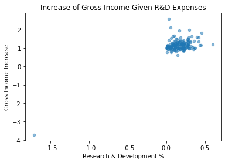

```python
import matplotlib.pyplot as plt

# Plotting data
plot = constituents.plot.scatter(x = "researchDevelopmentP", y = "increase", alpha=0.5)

# Labeling the graph
plot.set_xlabel("Research & Development %")
plot.set_ylabel("Gross Income Increase")
plot.set_title("Increase of Gross Income Given R&D Expenses")
```

[output not shown]

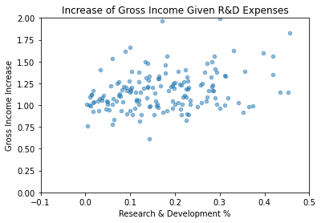

```python
plot = constituents.plot.scatter(x = "researchDevelopmentP", y = "increase", alpha=0.5)
plot.set_xlabel("Research & Development %")
plot.set_ylabel("Gross Income Increase")
plot.set_title("Increase of Gross Income Given R&D Expenses")

# Setting boundaries so we can see more clearly
plot.set_ylim(0, 2)
plot.set_xlim(-0.1, 0.5)
```

A simple scatterplot is good, but much more information can be conveyed. For this, seaborn will be used as it allows for easy color categorization for the sectors of the companies. Additionally, we will fit a line of regression to draw the general trend. This will also be used via seaborn since it allows for more complex and specific usage compared to Pandas. Scatterplots also hold some other key features such as showing outliers (which we crop), as well as if there is no correlation between two variables.

The type of visualization is crucial as there are multiple ways to show the relationships given different contexts. A few other examples are boxplots and violinplots when comparing between categories. Here, I chose scatterplot because I would like to draw line of regression to quickly see relationships. This can help determine whether high R&D costs hurt or help a company.

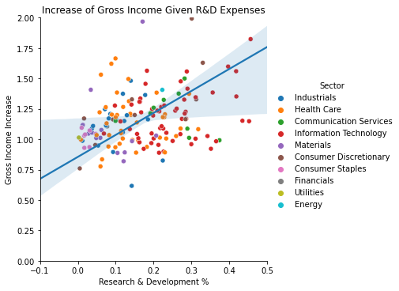

```python
import random
import seaborn as sns

# Changing the datatype to prevent errors do not like strings, so we create a copy of the current dataframe
constituents_copy = constituents.copy()
constituents_copy = constituents_copy.drop(["Sector", "Name", "Symbol"], axis=1)
#Getting unique sectors for the dataframe in order to assign colors to them
sector = constituents["Sector"].unique()
fg = sns.relplot(data=constituents, x = "researchDevelopmentP", y="increase", hue="Sector", hue_order=sector)
# Changing to float64 type so we can draw line of regression onto the graph
sns.regplot(x="researchDevelopmentP", y="increase", data=constituents_copy.astype('float64'), scatter=False)
fg.set(xlim=(-0.1, 0.5), ylim=(0, 2), xlabel="Research & Development %", ylabel="Gross Income Increase", title="Increase of Gross Income Given R&D Expenses")
```

As we can see, there is a general positive relation between the % of capital used in research and development and the increase in gross income. We can further distinguish this data by separating them and drawing separate lines of regression for the sectors. Overgeneralizing is a major pitfall we can avoid by continuously determining whether or not data need to be further subcategorized and avoiding irrelevant information being displayed.

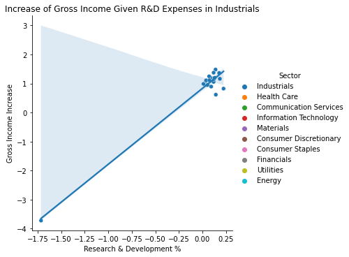

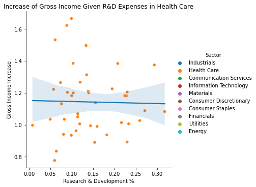

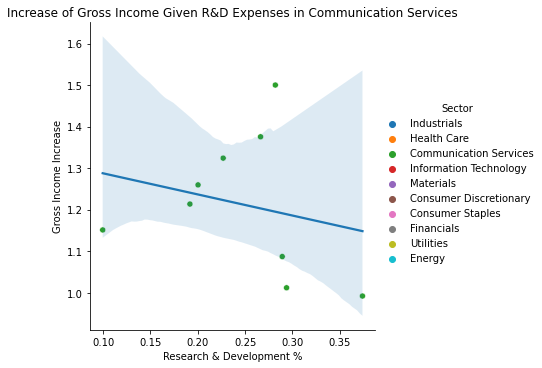

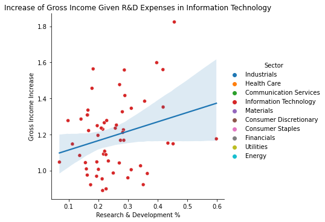

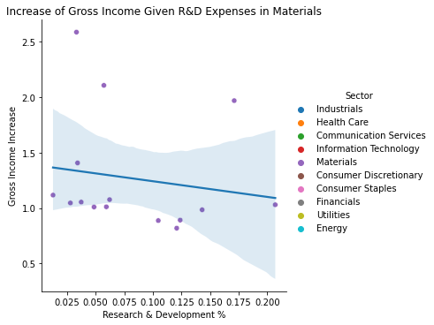

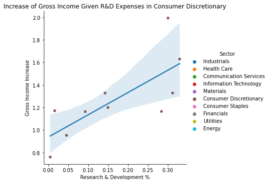

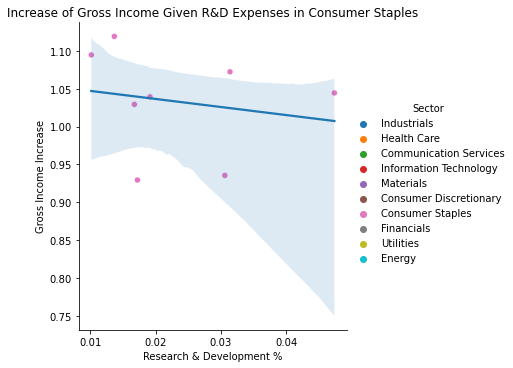

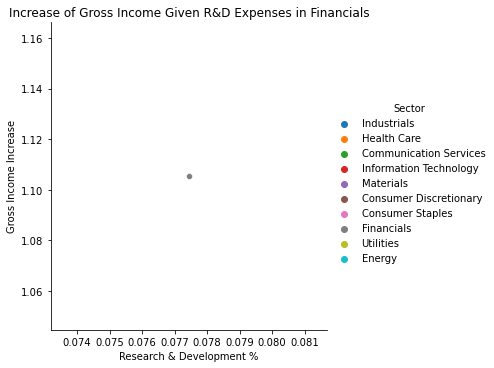

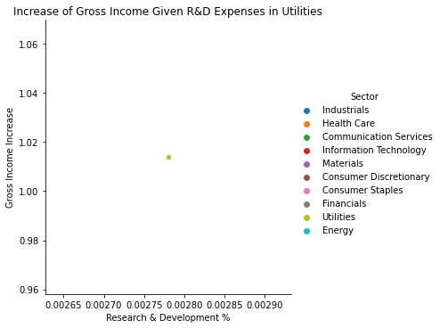

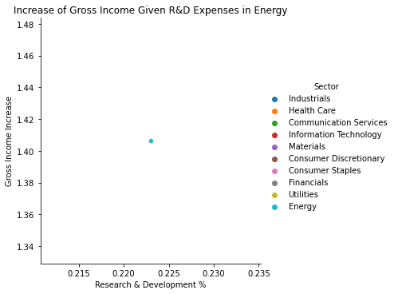

```python
# Iterating the sectors and grouping the dataframe by them
for sec in sector:
    curr = constituents.loc[constituents["Sector"] == sec]
    # Plotting each sectors into their own subplots
    fg = sns.relplot(data=curr, x = "researchDevelopmentP", y="increase", hue="Sector", hue_order=sector)

    curr = curr.drop(["Sector", "Name", "Symbol"], axis=1)
    sns.regplot(x="researchDevelopmentP", y="increase", data=curr.astype('float64'), scatter=False)
    fg.set(xlabel="Research & Development %", ylabel="Gross Income Increase", title="Increase of Gross Income Given R&D Expenses in "+sec)
```

The addition of linear regression is especially useful because it can draw out trends very quickly and is simple to understand. We can then try and understand why or how the trends have certain characteristics and further pursue applicable knowledge.

This is great proof when assuming that the information given is sufficient that although the big picture points one way, we must make sure that that is the case for certain compartments, otherwise we make wrong decisions. For instance, if we were to just make a blanket statement that R&D costs are good, we will end up losing returns on companies in the materials sector or opportunity cost in IT companies.

# CONCLUSION

In hindsight, it might've been better to make the tradeoff to larger array of companies rather than conforming ourselves to the S&P500. That way, we can have more accurate line of regression given there are more data points. Additionally, we can draw insight for sectors that were lacking such as Energy and Utilities. By having more test data, we can then confidently determine whether or not r&d percentage truly does have an impact and if so, what are the implications on respective sectors. We can also look for other data such as revenue, operational exepenses, the list goes on.

Another approach other than linear regression that can be used is machine learning models to train and test against. This can be done by having separated the data between training and testing, training the model using one, and then seeing how accurate it is by having the test data used for your model and comparing it with the real values. Very generally, there are two types: one is for predicting categories and another is predicting values based on information. Some machine models that can be used in this instance are linear SVM, non-linear-SVM, and k-NN classification.

Resource for companies and tickers: https://stockanalysis.com/stocks/

Resource for ML models: https://www.analyticsvidhya.com/blog/2021/01/a-quick-overview-of-regression-algorithms-in-machine-learning/

Note, it might be good to test your hypothesis by simulating your stock picking algorithm by fetching the historical data of said stocks, keep values of how the prices rise or fall, and seeing how it performs.